# Gex

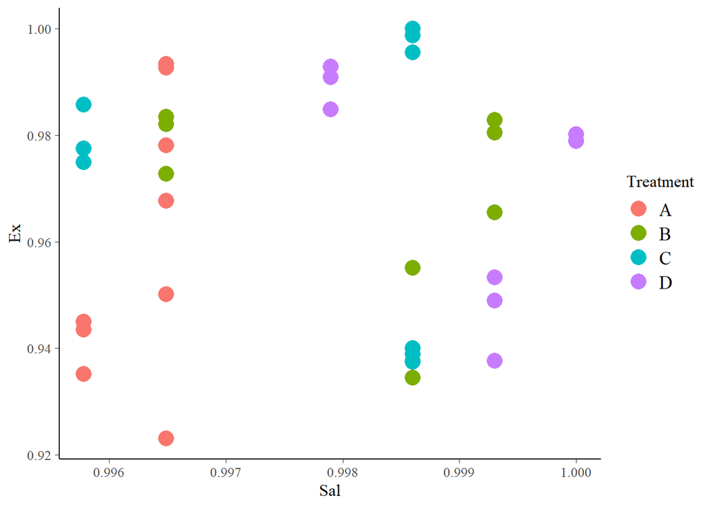

```r
ggplot(ca.stnd, aes(y=Ex, x=Sal, color=Treatment)) +
  geom_point(size=5)
```

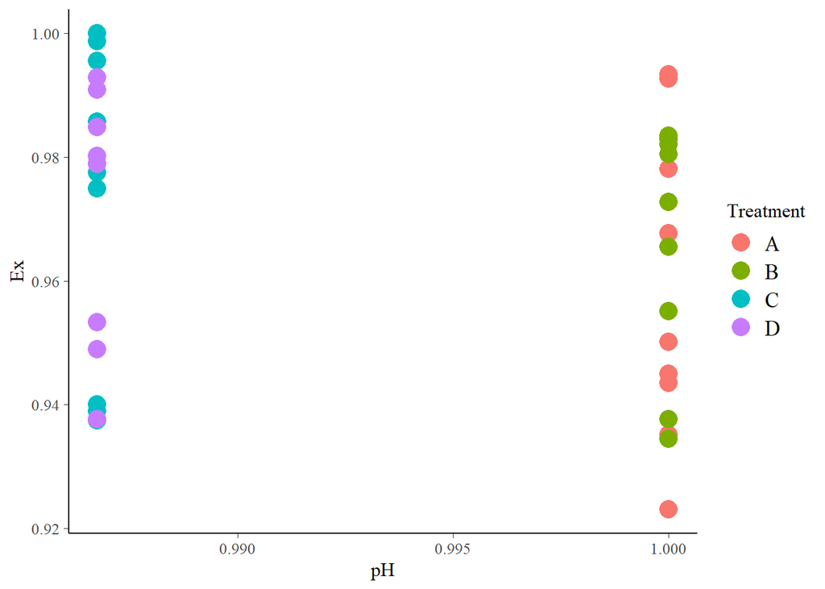

```r
ggplot(ca.stnd, aes(y=Ex, x=pH, color=Treatment)) +
  geom_point(size=5)
```

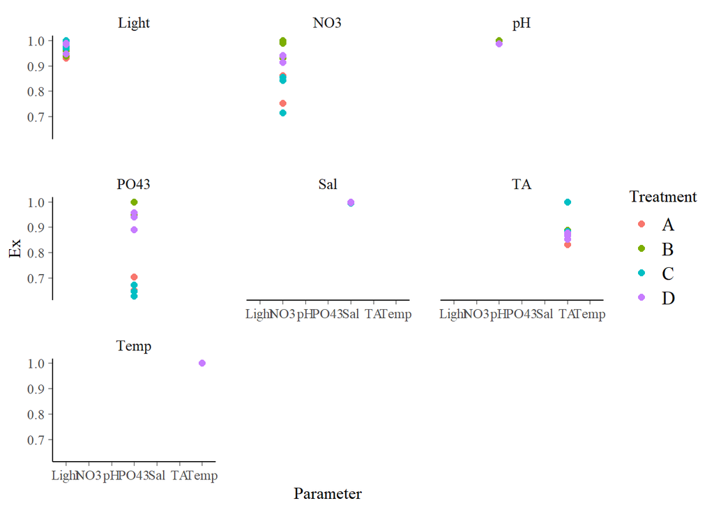

```r
ca.melt<-ca.stnd %>% gather(key=Parameter, value=Ex, Light:PO43)
ggplot(ca.melt, aes(y=Ex, x=Parameter, color=Treatment)) +
  geom_point(size=2) +
  facet_wrap(~Parameter)
```

I would like to put the single parameter on the x-axis, but don’t know how…

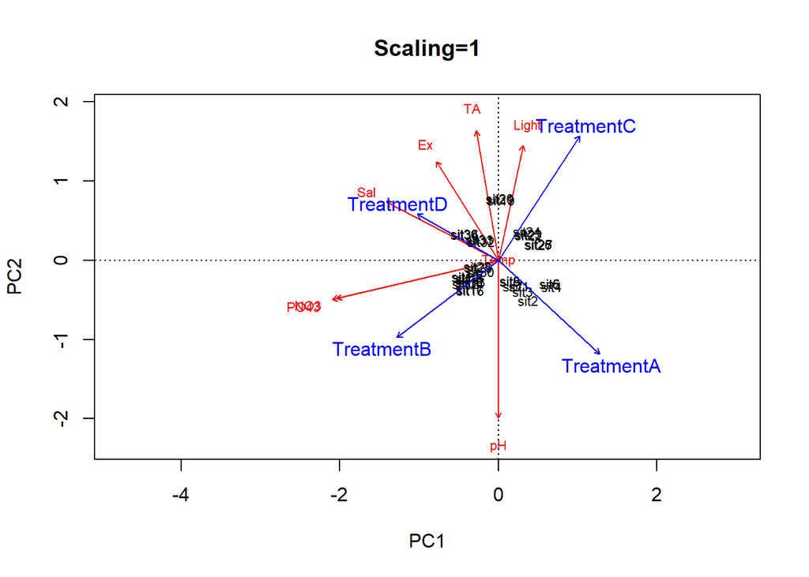

```r
biplot(ca.rda, scaling=1, main="Scaling=1")
Xmat = model.matrix(~-1+Treatment, data=ca)
plot(envfit(ca.rda, Xmat))
```

What does sit mean? is it sites? I need to adjust my data to the functions and see what I need to do to get what I want, which is the main driver of my expression rate.

Interpretation:

In treatment A no factor stands out.

In treatment B the main drivers are the nutrients PO43 and NO3.

In treatment C light mostly drives the expression rate.

In treatment D salinity is the main factor.

Get the values to the plot:

```r
ca.sites.scores<-as.data.frame(scores(ca.rda, display='sites'))
head(ca.sites.scores)
```

```
##            PC1        PC2
## sit1 0.4557370 -0.5969153
## sit2 0.6598489 -0.9377738
## sit3 0.5360540 -0.7310415
## sit4 1.1873316 -0.6120094
## sit5 1.1426143 -0.5373333
## sit6 1.1494252 -0.5487073
```

```r
ca.sites.scores<-data.frame(ca.sites.scores, ca)
head(ca.sites.scores)
```

```
##            PC1        PC2 Content Treatment ppm nut       Ex  Light Temp
## sit1 0.4557370 -0.5969153 Unkn-01         A low low 2037.972 148.12 25.8
## sit2 0.6598489 -0.9377738 Unkn-01         A low low 1687.231 148.12 25.8
## sit3 0.5360540 -0.7310415 Unkn-01         A low low 1894.013 148.12 25.8
## sit4 1.1873316 -0.6120094 Unkn-02         A low low 1777.996 176.12 25.8
## sit5 1.1426143 -0.5373333 Unkn-02         A low low 1853.523 176.12 25.8
## sit6 1.1494252 -0.5487073 Unkn-02         A low low 1841.867 176.12 25.8
##       Sal  pH  TA   NO3  PO43
## sit1 35.3 7.7 425 5.349 0.153
## sit2 35.3 7.7 425 5.349 0.153
## sit3 35.3 7.7 425 5.349 0.153
## sit4 35.2 7.7 360 3.168 0.135
## sit5 35.2 7.7 360 3.168 0.135
## sit6 35.2 7.7 360 3.168 0.135
```

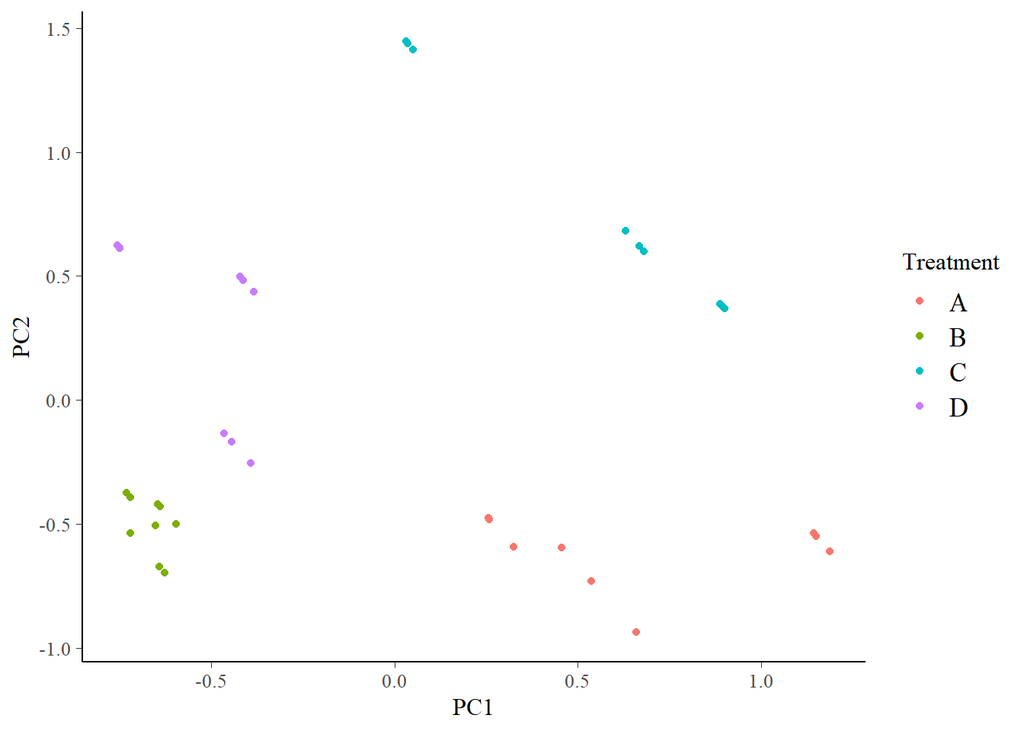

```r
ggplot() +
  geom_point(data=ca.sites.scores, aes(y=PC2, x=PC1, color=Treatment))
```

```r
#ca.species.scores<-as.data.frame(scores(ca.rda, display='treatments'))
#head(ca.sites.scores)
```

```r
ca.sites.scores<-data.frame(ca.sites.scores, ca)
head(ca.sites.scores)
```

```
##            PC1        PC2 Content Treatment ppm nut       Ex  Light Temp
## sit1 0.4557370 -0.5969153 Unkn-01         A low low 2037.972 148.12 25.8
## sit2 0.6598489 -0.9377738 Unkn-01         A low low 1687.231 148.12 25.8
## sit3 0.5360540 -0.7310415 Unkn-01         A low low 1894.013 148.12 25.8
## sit4 1.1873316 -0.6120094 Unkn-02         A low low 1777.996 176.12 25.8
## sit5 1.1426143 -0.5373333 Unkn-02         A low low 1853.523 176.12 25.8
## sit6 1.1494252 -0.5487073 Unkn-02         A low low 1841.867 176.12 25.8
##       Sal  pH  TA   NO3  PO43 Content.1 Treatment.1 ppm.1 nut.1     Ex.1
## sit1 35.3 7.7 425 5.349 0.153   Unkn-01           A   low   low 2037.972
## sit2 35.3 7.7 425 5.349 0.153   Unkn-01           A   low   low 1687.231
## sit3 35.3 7.7 425 5.349 0.153   Unkn-01           A   low   low 1894.013
## sit4 35.2 7.7 360 3.168 0.135   Unkn-02           A   low   low 1777.996
## sit5 35.2 7.7 360 3.168 0.135   Unkn-02           A   low   low 1853.523
## sit6 35.2 7.7 360 3.168 0.135   Unkn-02           A   low   low 1841.867
##      Light.1 Temp.1 Sal.1 pH.1 TA.1 NO3.1 PO43.1
## sit1  148.12   25.8  35.3  7.7  425 5.349  0.153
## sit2  148.12   25.8  35.3  7.7  425 5.349  0.153
## sit3  148.12   25.8  35.3  7.7  425 5.349  0.153
## sit4  176.12   25.8  35.2  7.7  360 3.168  0.135
## sit5  176.12   25.8  35.2  7.7  360 3.168  0.135
## sit6  176.12   25.8  35.2  7.7  360 3.168  0.135
```

```r
#ca.species.scores$Parameters<-rownames(ca.species.scores)

#hjust<-ifelse(ca.species.scores$PC1>0,0,1)
#vjust<-ifelse(ca.species.scores$PC2>0,0,1)

#ggplot() +
  #geom_point(data=ca.sites.scores, aes(y=PC2, x=PC1, color=Treat)) +
  #geom_text(data=ca.sites.scores, aes(y=PC2, x=PC1, label=Treat, hjust=-0.2, color=Treat),
            #show.legend=FALSE) +
  #geom_segment(data=ca.species.scores, aes(y=0, x=0, yend=PC2, xend=PC1),
               #arrow=arrow(length=unit(0.3,'lines'))) +
 # geom_segment(data=NULL, aes(y=-Inf, x=0, yend=Inf, xend=0), linetype='dotted') +
  #geom_segment(data=NULL, aes(y=0, x=-Inf, yend=0, xend=Inf), linetype='dotted') +
  #theme_classic() +
  #geom_text(data=ca.species.scores,
                #aes(y=PC2, x=PC1, label=Species), hjust=hjust, vjust=vjust)
```

#### Stop here! This is the R-Mode and due to our lack in linearity, we should run a Q-Mode Analysis. So first we standardize

```r
#now we forth root transform (put down notes from rec) the variables to normalize and help out with linearity, which we have
# decostand(.^0,25, MARGIN=2, 'max'): to do standardizations; MARGIN=2 is column, MARGIN=1 is rows, so we standardize to the maximum of the columns
#ca.stnd1=ca %>% mutate_if(is.numeric, funs(decostand(.^0.25, MARGIN=2, 'max')))

#ca.stnd1<- wisconsin(ca[,-1]^0.25)
```

Doesn’t work. What should I do?

I think an ANCOVA is the correct thing to do.

```r
ca.lmppm<-lm(Ex~ppm, data=ca)
```

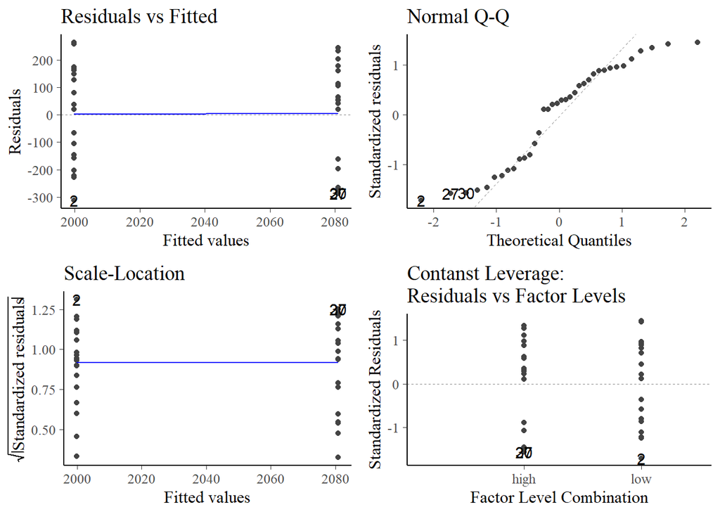

```r
autoplot(ca.lmppm)
```

**Result** : Rubbish!

## GAM

**Don’t fit a GAM, because your main predictors nut and ppm are not dependng on each others. Unless you would use, pH, TA, etc. as predictors, which you don’t. So drop this model fitting!**

non-linear generalized additive models

Since a GAM is just a penalized GLM, residual plots should be checked, exactly as for a GLM.

1. How many splines?
2. How many knots? We increase the number of knots due to our small dataset.
3. Which kind of spline? # bs is base of the spline # cp means penalized cubic spline # tp stands for thin plate.

I believe the best is to have a penalized spline, since it means that the spread of my data is not uniform. I need a different spacing of knots.

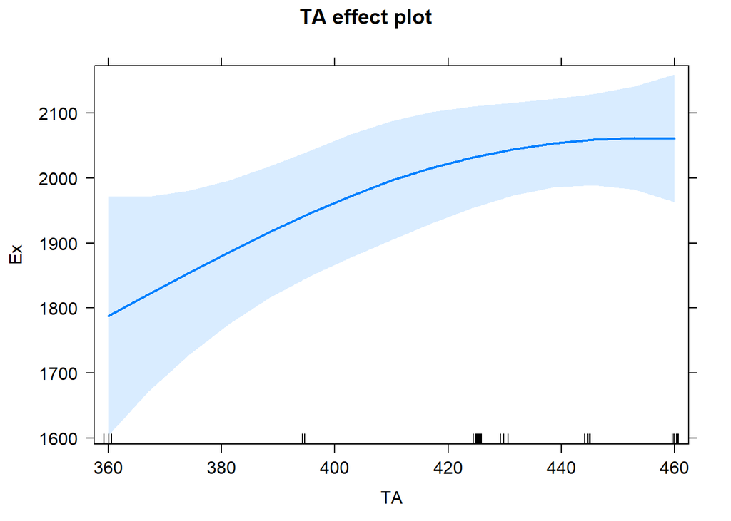

```r
# fitting a spline of two knots, which why we add ns
# degress of freedom is minus one, knots are 2
ca1.spline2=lm(Ex~ns(TA, df=2), data=ca1)
plot(allEffects(ca1.spline2, partial.resid=TRUE),
     partial.residuals=list(smooth=FALSE))
```

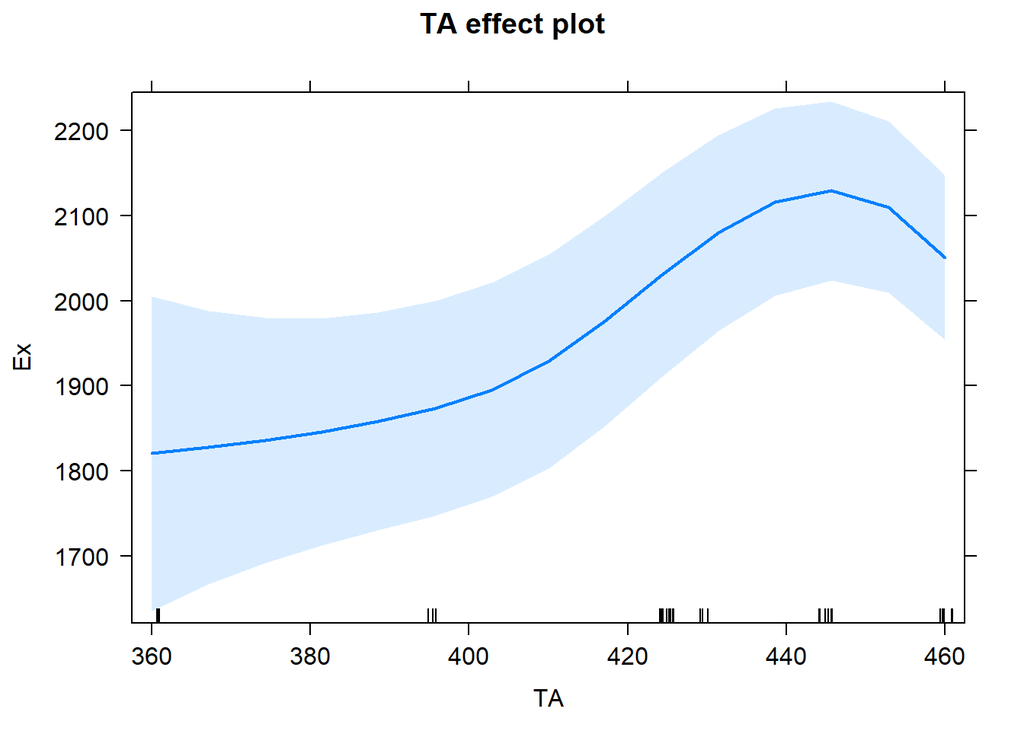

```r
ca1.spline3=lm(Ex~ns(TA, df=3), data=ca1)
plot(allEffects(ca1.spline3, partial.resid=TRUE),
     partial.residuals=list(smooth=FALSE))
```

```r
# this is our fitting with three knots,
```

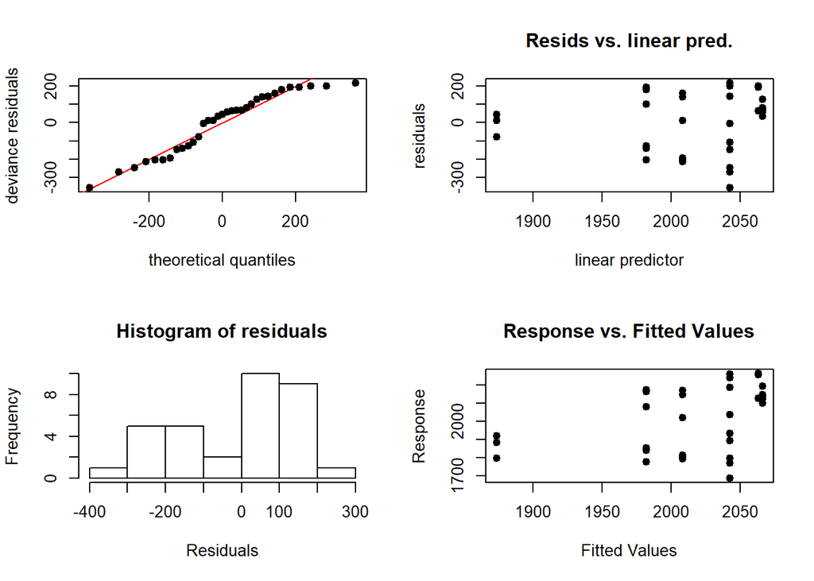

```
##
## Method: GCV   Optimizer: magic
## Smoothing parameter selection converged after 6 iterations.
## The RMS GCV score gradient at convergence was 0.02584884 .
## The Hessian was positive definite.
## Model rank =  3 / 3
##
## Basis dimension (k) checking results. Low p-value (k-index<1) may
## indicate that k is too low, especially if edf is close to k'.
##
##        k' edf k-index p-value
## s(TA) 2.0 1.6    0.42  <2e-16 ***
## ---
## Signif. codes:  0 '***' 0.001 '**' 0.01 '*' 0.05 '.' 0.1 ' ' 1
```

```r
# pch is the plotting character 19, which is a solid dot
# to plot a gam use gam.check
ca1.cp3.gam<-gam(Ex~s(TA, k=3, bs='cp'), data=ca1)
gam.check(ca1.cp3.gam, pch=19)
```

**Result** : The residuals are still not normally distributed (see histogram). Also, there is still a pattern in the response vs. fitted values.

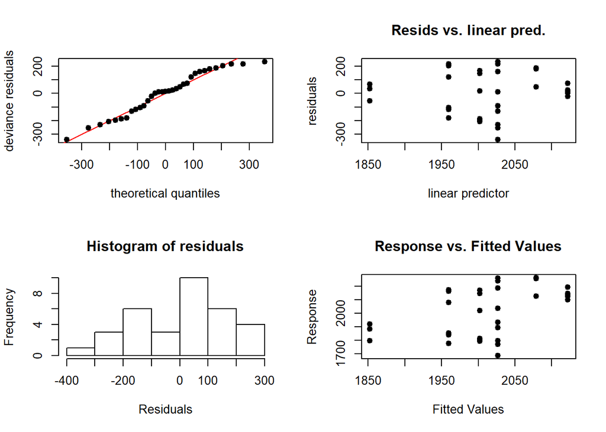

```
##
## Method: GCV   Optimizer: magic
## Smoothing parameter selection converged after 7 iterations.
## The RMS GCV score gradient at convergence was 0.3151101 .
## The Hessian was positive definite.
## Model rank =  4 / 4
##
## Basis dimension (k) checking results. Low p-value (k-index<1) may
## indicate that k is too low, especially if edf is close to k'.
##
##         k'  edf k-index p-value
## s(TA) 3.00 2.35    0.47  <2e-16 ***
## ---
## Signif. codes:  0 '***' 0.001 '**' 0.01 '*' 0.05 '.' 0.1 ' ' 1
```

```r
ca1.cp4.gam<-gam(Ex~s(TA, k=4, bs='cp'), data=ca1)
gam.check(ca1.cp4.gam, pch=19)
```

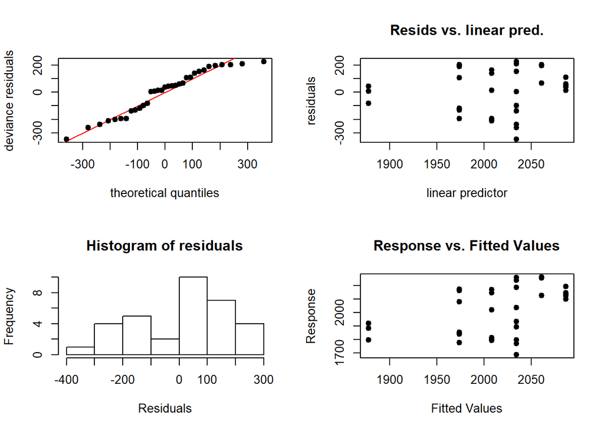

```
##
## Method: GCV   Optimizer: magic
## Smoothing parameter selection converged after 4 iterations.
## The RMS GCV score gradient at convergence was 0.3114906 .
## The Hessian was positive definite.
## Model rank =  5 / 5
##
## Basis dimension (k) checking results. Low p-value (k-index<1) may
## indicate that k is too low, especially if edf is close to k'.
##
##         k'  edf k-index p-value
## s(TA) 4.00 1.82    0.43  <2e-16 ***
## ---
## Signif. codes:  0 '***' 0.001 '**' 0.01 '*' 0.05 '.' 0.1 ' ' 1
```

```r
ca1.cp5.gam<-gam(Ex~s(TA, k=5, bs='cp'), data=ca1)
gam.check(ca1.cp5.gam, pch=19)
```

Compare model with **AIC**:

```r
AIC(ca1.cp3.gam, ca1.cp4.gam, ca1.cp5.gam)
```

```
##                   df      AIC
## ca1.cp3.gam 3.596603 436.1160
## ca1.cp4.gam 4.348344 435.2375
## ca1.cp5.gam 3.816636 435.7014
```

**Result** : models are not satisfying due to the non normality in the histogram.

## para dataset

To have a look at the nutrient levels over time during my 3 days experiment, we need to upload the para csv file, because I took samples for nitrate, nitrite and phosphate after 24, 48 and 72 hours during my experiment.

```r
para<-read.csv('C:/Users/admin/Desktop/Paper CA/Gex/para.csv', strip.white=T)
head(para)
```

```
##   Content Time Treat  Light Temp   Sal  pH  TA   NO3  PO43   NO2
## 1 Unkn-01    0     A 113.87 25.9 34.25 7.6 630 4.857 0.540 1.070
## 2 Unkn-01   24     A 148.12 25.8 34.50 7.7 470 4.773 0.133 0.997
## 3 Unkn-01   48     A 148.12 25.8 34.70 7.7 565 6.273 0.128 1.020
## 4 Unkn-01   72     A 148.12 25.8 35.30 7.7 425 5.349 0.153 1.102
## 5 Unkn-02    0     A 105.12 25.9 34.25 7.6 630 4.857 0.540 1.070
## 6 Unkn-02   24     A 176.12 25.8 34.50 7.7 500 4.550 0.140 0.968
```

```r
summary(para)
```

```
##     Content        Time    Treat      Light             Temp
##  Unkn-01: 4   Min.   : 0   A:12   Min.   : 81.92   Min.   :25.80
##  Unkn-02: 4   1st Qu.:18   B:12   1st Qu.:136.62   1st Qu.:25.80
##  Unkn-03: 4   Median :36   C:12   Median :157.81   Median :25.80
##  Unkn-04: 4   Mean   :36   D:12   Mean   :149.13   Mean   :25.82
##  Unkn-05: 4   3rd Qu.:54          3rd Qu.:172.31   3rd Qu.:25.82
##  Unkn-06: 4   Max.   :72          Max.   :190.29   Max.   :25.90
##  (Other):24
##       Sal              pH              TA          NO3
##  Min.   :34.25   Min.   :7.300   580    : 6   Min.   : 2.583
##  1st Qu.:34.36   1st Qu.:7.300   630    : 6   1st Qu.: 4.862
##  Median :34.70   Median :7.600   425    : 5   Median : 6.573
##  Mean   :34.78   Mean   :7.525   430    : 3   Mean   : 7.182
##  3rd Qu.:35.05   3rd Qu.:7.700   445    : 3   3rd Qu.: 9.568
##  Max.   :35.80   Max.   :7.700   465    : 3   Max.   :11.852
##                                  (Other):22
##       PO43             NO2
##  Min.   :0.1050   Min.   :0.5980
##  1st Qu.:0.1422   1st Qu.:0.9157
##  Median :0.5400   Median :1.0050
##  Mean   :0.5737   Mean   :0.9724
##  3rd Qu.:0.8522   3rd Qu.:1.0700
##  Max.   :1.3020   Max.   :1.3200
##
```

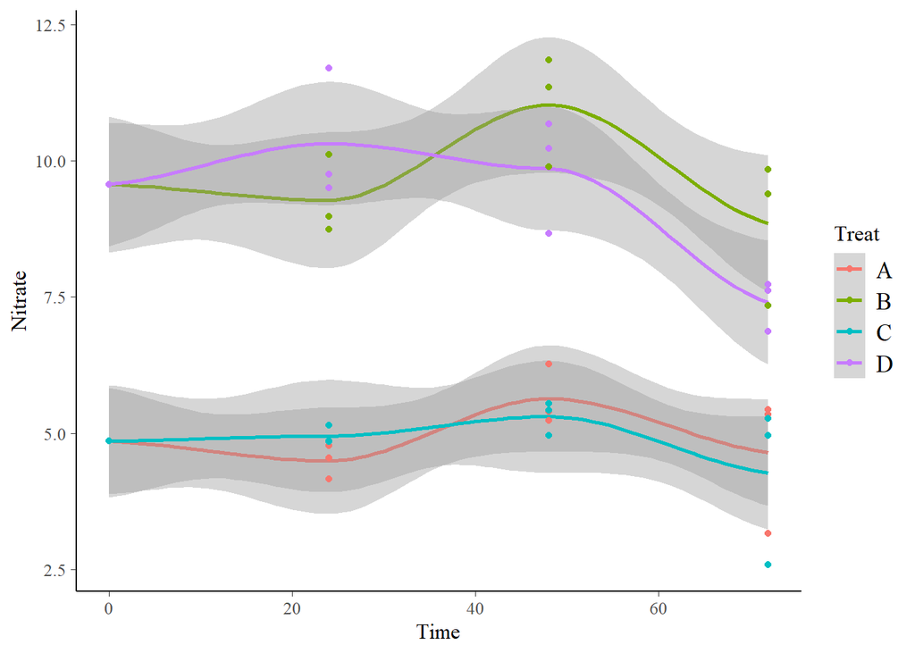

```r
ggplot(para, aes(y=NO3, x=Time)) +
  geom_smooth(aes(y=NO3, x=Time, colour=Treat)) +
  geom_point(aes(y=NO3, x=Time, colour=Treat)) +
  ylab("Nitrate")
```

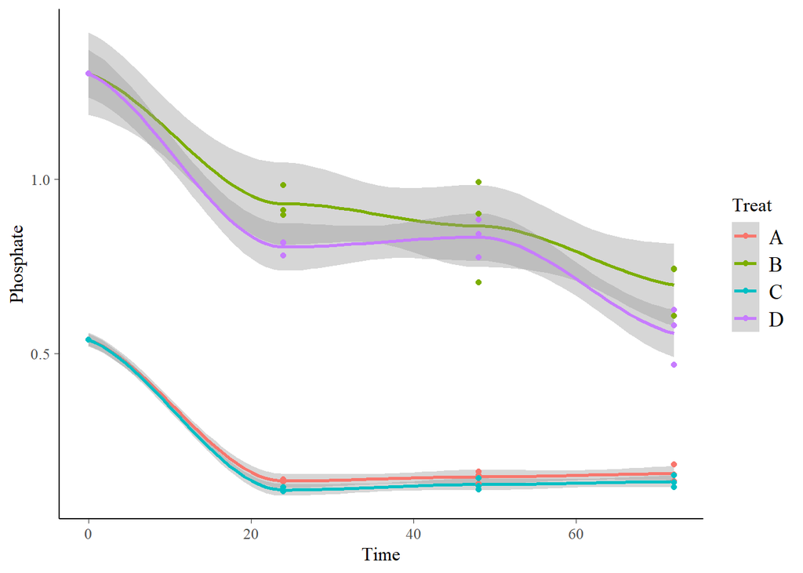

```r
ggplot(para, aes(y=PO43, x=Time)) +
  geom_smooth(aes(y=PO43, x=Time, colour=Treat)) +
  geom_point(aes(y=PO43, x=Time, colour=Treat)) +
  ylab("Phosphate")
```

I can see consumption of PO4 3- (and some of NO3) during my experiment across all the treatments.

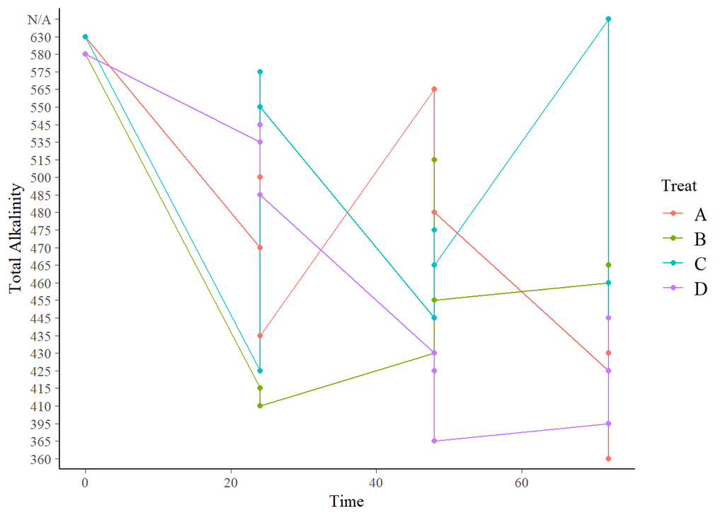

```r
ggplot(para, aes(y=TA, x=Time)) +
  geom_line(aes(y=TA, x=Time, group=Treat, colour=Treat)) +
  geom_point(aes(y=TA, x=Time, colour=Treat)) +
  ylab("Total Alkalinity")
```

How do I give sense to the lines? A smooth wouldn’t work…